# 06_SVM_tSNE

## **5. Aplicación de Modelos**

### Librerías

```python
from sklearn import svm
from funciones_metricas import *
from sklearn.metrics import classification_report

import matplotlib.pyplot as plt
import numpy as np
import pandas as pd
import seaborn as sns
import scikitplot as skp

import warnings
warnings.filterwarnings('ignore')
```

### Carga de datos

```python
path_folder = "./"
x_train_1 = pd.read_csv(path_folder +"Xtrain1_data.csv", low_memory=False)
x_val = pd.read_csv(path_folder +"Xval_data.csv", low_memory=False)

y_train_1 = pd.read_csv(path_folder +"ytrain1_data.csv", low_memory=False)
y_val = pd.read_csv(path_folder +"yval_data.csv", low_memory=False)
```

### 7. Suppport Vector Machine

Se trata de un algoritmo de aprendizaje supervisado que se puede emplear para clasificación. Su objetivo es encontrar un hiperplano óptimo que sea capaz de separar las instancias de diferentes clases en el espacio de características.

Fuente: https://scikit-learn.org/stable/modules/svm.html

#### 7.1 Inspección de datos

```python
x_train = x_train_1
y_train = y_train_1
```

#### 7.2 Modelado

**Parámetros**

1. Kernel = 'linear' esto implica que el modelo buscará un hiperplano lineal de separación.
2. C = 1.0 esto implica que hay una penalización moderada por errores de clasificación, buscando así un equilibrio entre un margen amplio y una clasificación más precisa.

```python
#Entrenamiento
model_svm = svm.SVC(kernel='linear', C=1.0)
model_svm.fit(x_train, y_train)
```

```
SVC(kernel='linear')
```

```python
#Prediccion
y_pred = model_svm.predict(x_val)
```

#### 7.3 Evaluación del modelo

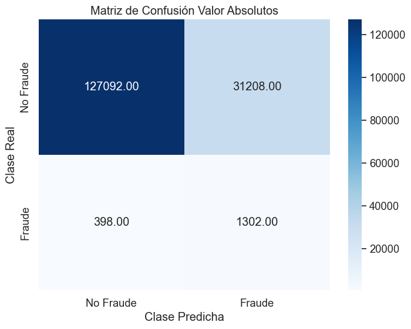

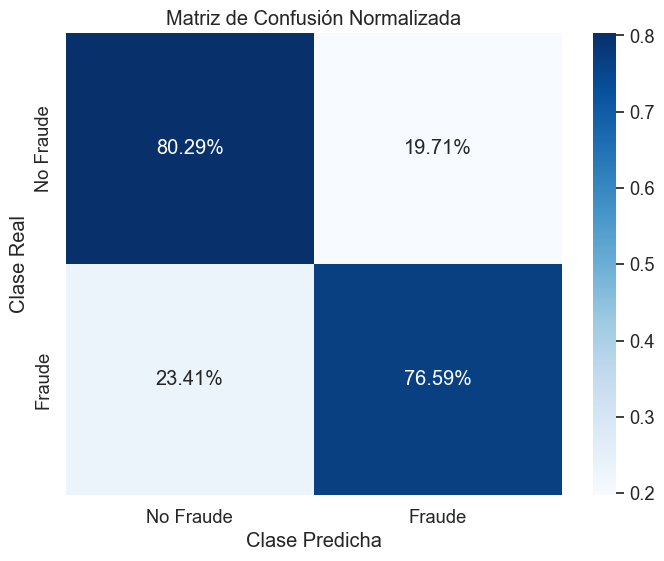

```python
plot_confusion_matrices(y_val, y_pred)
```

```python
calcular_accuracy_score(y_val, y_pred)
```

```
0.8024625
```

El accuracy está en el 80%. Esto es un resultado muy similar a los otros modelos entrenados.

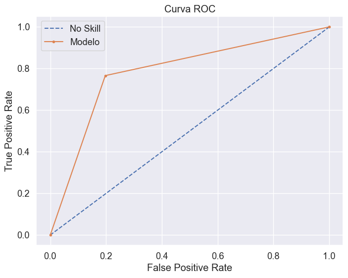

```python
plot_roc_curve(y_val, y_pred)
```

La curva ROC presenta una mejora en la predicción en comparación con la realidad. Se cuenta con una tasa de verdaderos positivos cercana a un 80%.

```
Best Threshold=1.000, F-Score=0.076
```

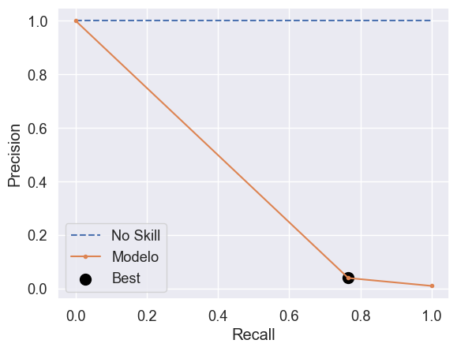

```
F-Score: 0.07612
```

```
(1, 0.07611809412452498)
```

```python
evaluar_modelo_precision_recall(y_val, y_pred)
```

El F-Score=0.076 no es muy elevado por lo que es necesario prestar atención a la precisión, más que a la sensibilidad con el fin de poder equilibrar entre estas dos métricas.

```python
print(classification_report(y_val, y_pred))
```

```
              precision    recall  f1-score   support

           0       1.00      0.80      0.89    158300
           1       0.04      0.77      0.08      1700

    accuracy                           0.80    160000
   macro avg       0.52      0.78      0.48    160000
weighted avg       0.99      0.80      0.88    160000
```

### t-SNE

Queríamos dedicar un apartado a explicar por qué no se ha hecho uso de este modelo para realizar la predicción del fraude en cuentas bancarias en línea. Estos son los motivos:

1. **Falta de capacidad predictiva directa:** El t-SNE es una técnica de reducción de dimensionalidad que se utiliza comúnmente para visualizar datos en un espacio de menor dimensión. Sin embargo, no está diseñado para realizar predicciones directas, como identificar transacciones fraudulentas. Su enfoque principal no garantiza una capacidad predictiva significativa para problemas de clasificación, como es, en este caso, la detección de fraudes.
2. **No supervisión y falta de interpretabilidad:** El t-SNE es un algoritmo no supervisado, lo que significa que no utiliza etiquetas de clase para guiar su proceso de reducción de dimensionalidad. En el contexto de la detección de fraudes, la falta de supervisión puede ser una desventaja, ya que el modelo no aprende de manera explícita qué características están relacionadas con las transacciones fraudulentas. Además, la interpretación de los resultados de t-SNE puede ser compleja, lo que dificulta la comprensión de las características específicas que contribuyen a la identificación de fraudes.
3. **Sensibilidad a los parámetros:** El t-SNE es sensible a la elección de parámetros, lo que puede llevar a resultados diferentes en ejecuciones distintas. Esto, puede dificultar la reproducibilidad y la consistencia en la detección de fraudes, ya que pequeñas variaciones en los datos o en los parámetros pueden generar resultados significativamente distintos. En problemas críticos como la detección de fraudes bancarios, es esencial contar con modelos más robustos y predecibles.

Fuente: https://scikit-learn.org/stable/modules/generated/sklearn.manifold.TSNE.html